# Text Mining

[figure not shown]

We use the Netflix data at [this Kaggle link](https://www.kaggle.com/shivamb/netflix-shows). This tabular dataset consists of listings of all the movies and tv shows available on Netflix, along with details such as - cast, directors, ratings, release year, duration, etc. The text data that will be analyzed is stored in the `description` variable. The data can be downloaded at this link.

```r
library(tidyverse)
library(tidytext)
library(knitr)
df <- readr::read_csv('data/netflix_titles.csv')

df %>%
  head(2) %>%
  kable()
```

| show_id | type | title | director | cast | country | date_added | release_year | rating | duration | listed_in | description |
| --- | --- | --- | --- | --- | --- | --- | --- | --- | --- | --- | --- |
| s1 | TV Show | 3% | NA | João Miguel, Bianca Comparato, Michel Gomes, Rodolfo Valente, Vaneza Oliveira, Rafael Lozano, Viviane Porto, Mel Fronckowiak, Sergio Mamberti, Zezé Motta, Celso Frateschi | Brazil | August 14, 2020 | 2020 | TV-MA | 4 Seasons | International TV Shows, TV Dramas, TV Sci-Fi & Fantasy | In a future where the elite inhabit an island paradise far from the crowded slums, you get one chance to join the 3% saved from squalor. |
| s2 | Movie | 7:19 | Jorge Michel Grau | Demián Bichir, Héctor Bonilla, Oscar Serrano, Azalia Ortiz, Octavio Michel, Carmen Beato | Mexico | December 23, 2016 | 2016 | TV-MA | 93 min | Dramas, International Movies | After a devastating earthquake hits Mexico City, trapped survivors from all walks of life wait to be rescued while trying desperately to stay alive. |

## 1. Word Frequency

- A token is a meaningful unit of text.
- One row of text will be converted to multiple rows of tokens.

### By TV Show

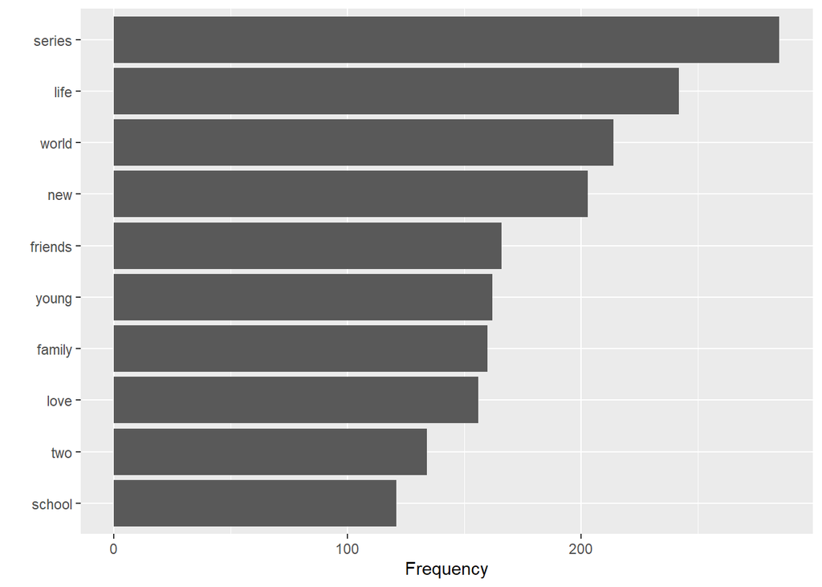

```r
df %>%
  unnest_tokens(input = description, output = word) %>%
  anti_join(get_stopwords()) %>%
  count(type, word, sort = TRUE) %>%
  filter(type=='TV Show') %>%
  head(10) %>%
  ggplot(aes(x = n, y = reorder(word, n))) +
  geom_col() +
  labs(y = '', x = 'Frequency')
```

### TV Show vs. Movies

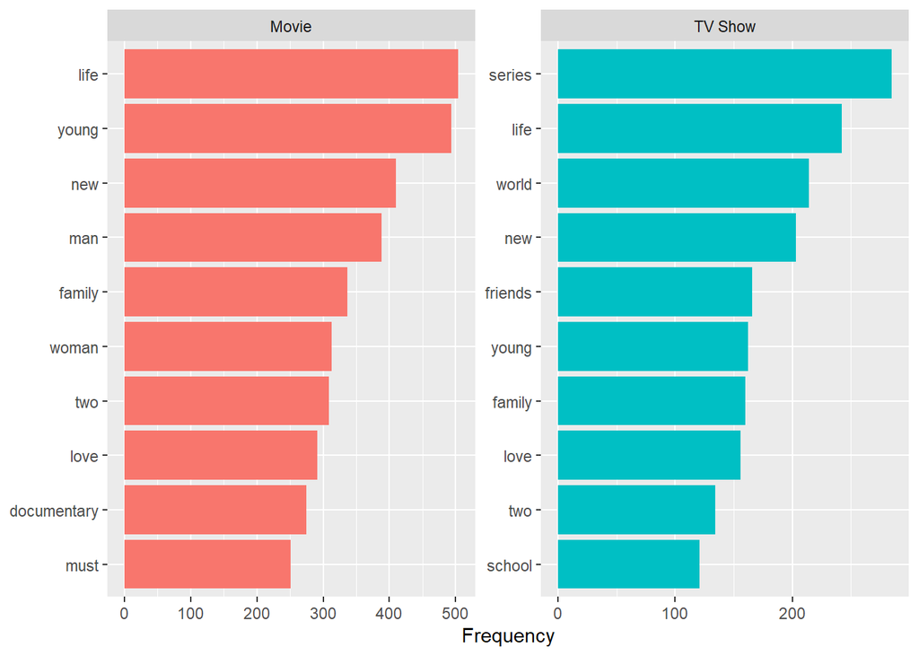

```r
df %>%
  unnest_tokens(input = description, output = word) %>%
  anti_join(get_stopwords()) %>%
  count(type, word, sort = TRUE) %>%
  group_by(type) %>%
  slice_max(n, n = 10) %>%
  ungroup() %>%
  mutate(word = reorder_within(word, by = n, within = type)) %>%
  ggplot(aes(n, word, fill = type)) +
  geom_col(show.legend = FALSE) +
  facet_wrap(~type, scales = "free") +
  labs(x = "Frequency",
       y = NULL)+
  scale_y_reordered()
```

## 2. Word Cloud

### Total Word Cloud

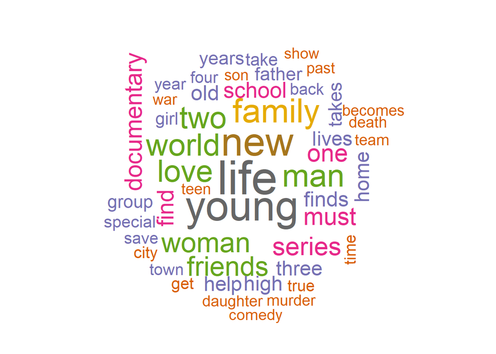

```r
library(wordcloud)
pal <- brewer.pal(8,"Dark2")

df %>%
  unnest_tokens(input = description, output = word) %>%
  anti_join(get_stopwords()) %>%
  count(word, sort = TRUE) %>%
  with(wordcloud(word, n, random.order = FALSE, max.words = 50, colors=pal))
```

### By Movie

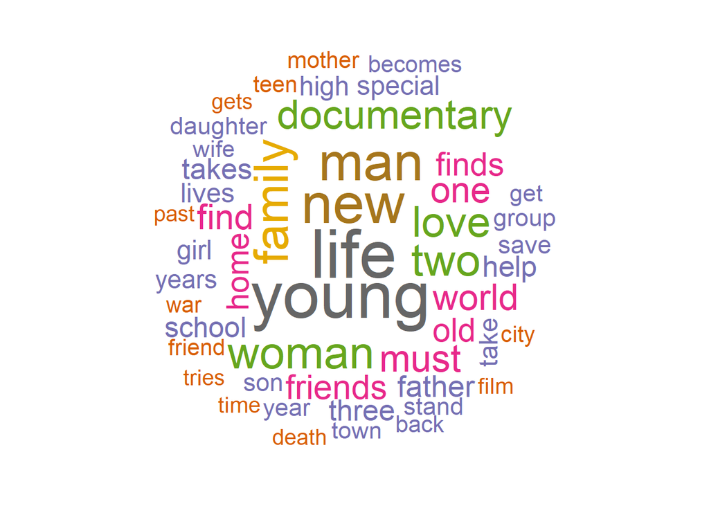

```r
library(wordcloud)
pal <- brewer.pal(8,"Dark2")

df %>%
  filter(type =='Movie') %>%
  unnest_tokens(input = description, output = word) %>%
  anti_join(get_stopwords()) %>%
  count(type, word, sort = TRUE) %>%
  with(wordcloud(word, n, random.order = FALSE, max.words = 50, colors=pal))
```

## 3. Sentiment Analysis

A word is converted to a sentiment measure.

- `nrc` converts a word into positive, negative, anger, anticipation, disgust, fear, joy, sadness, surprise, or trust.
- `bing` converts a word into positive or negative
- `AFINN` converts a word into a score that runs between -5 (max negative) and 5 (max positive).

### By `bing`

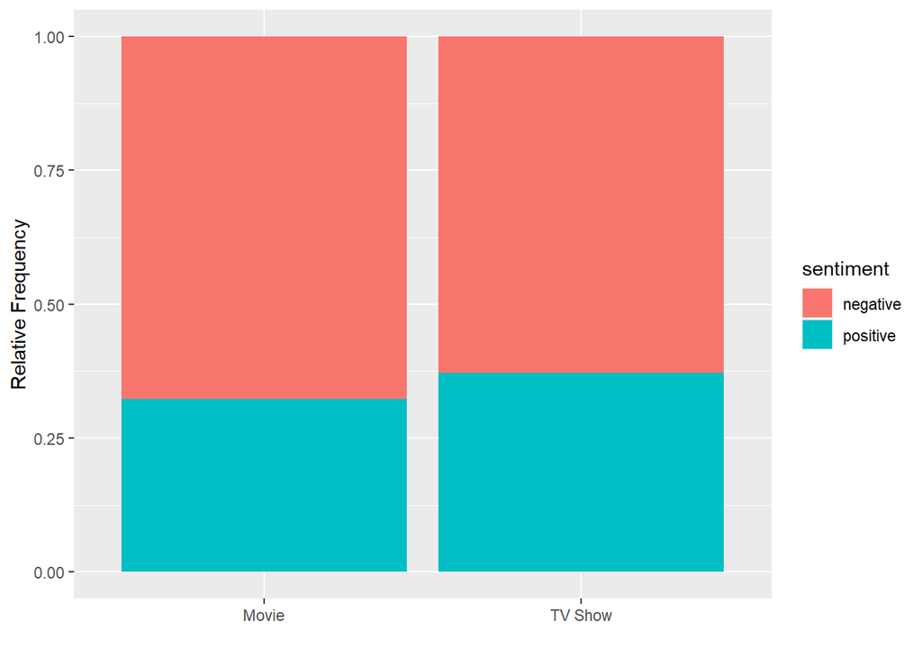

```r
df %>%
    unnest_tokens(input = description, output = word) %>%
    anti_join(get_stopwords()) %>%
    count(type, word, sort = TRUE) %>%
    group_by(type) %>%
    inner_join(get_sentiments("bing")) %>%
    filter(!is.na(sentiment)) %>%
    count(sentiment, sort = TRUE) %>%
    group_by(type) %>%
    mutate(n = n/sum(n)) %>%
    ggplot(aes(type, n, fill=sentiment))+geom_col(position = 'fill')+
    labs(y='Relative Frequency', x ='')
```

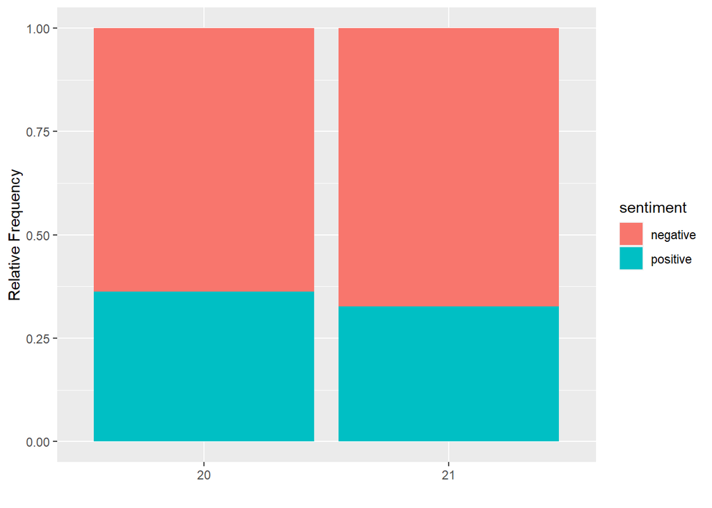

```r
df %>%
    mutate(century = if_else(release_year>=2000, '21','20')) %>%
    unnest_tokens(input = description, output = word) %>%
    anti_join(get_stopwords()) %>%
    count(century, word, sort = TRUE) %>%
    group_by(century) %>%
    inner_join(get_sentiments("bing")) %>%
    filter(!is.na(sentiment)) %>%
    count(sentiment, sort = TRUE) %>%
    group_by(century) %>%
    mutate(n = n/sum(n)) %>%
    ggplot(aes(century, n, fill=sentiment))+geom_col(position = 'fill')+
    labs(y='Relative Frequency', x ='')
```

### By `nrc`

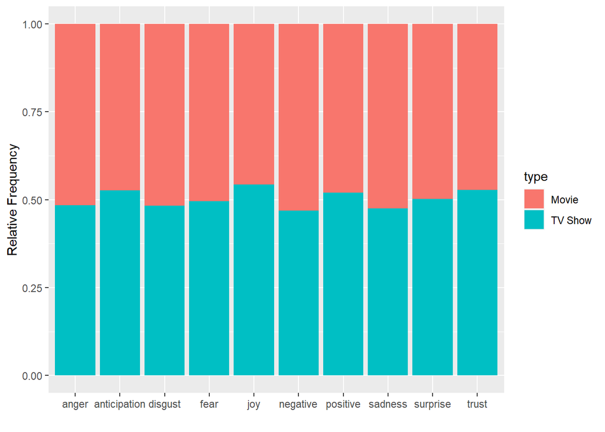

```r
df %>%
    unnest_tokens(input = description, output = word) %>%
    anti_join(get_stopwords()) %>%
    count(type, word, sort = TRUE) %>%
    group_by(type) %>%
    inner_join(get_sentiments("nrc")) %>%
    filter(!is.na(sentiment)) %>%
    count(sentiment, sort = TRUE) %>%
    group_by(type) %>%
    mutate(n = n/sum(n)) %>%
    ggplot(aes(sentiment, n, fill=type))+geom_col(position = 'fill')+
    labs(y='Relative Frequency', x ='')
```

### By `afinn`

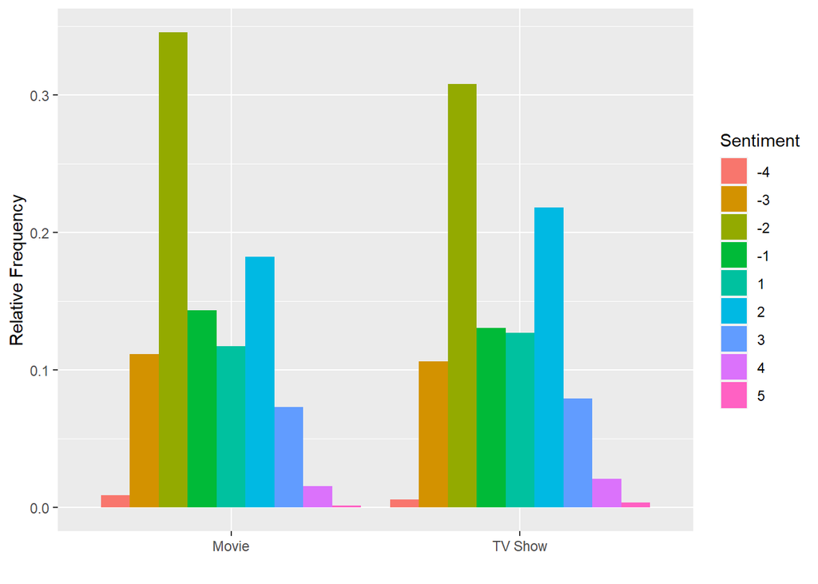

```r
df %>%
    unnest_tokens(input = description, output = word) %>%
    anti_join(get_stopwords()) %>%
    count(type, word, sort = TRUE) %>%
    group_by(type) %>%
    inner_join(get_sentiments("afinn")) %>%
    mutate(sentiment = value) %>%
    filter(!is.na(sentiment)) %>%
    count(sentiment, sort = TRUE) %>%
    group_by(type) %>%
    mutate(n = n/sum(n)) %>%
    ggplot(aes(type, n, fill=factor(sentiment)))+geom_col(position = 'dodge')+
    labs(y='Relative Frequency', fill = 'Sentiment', x = '')
```

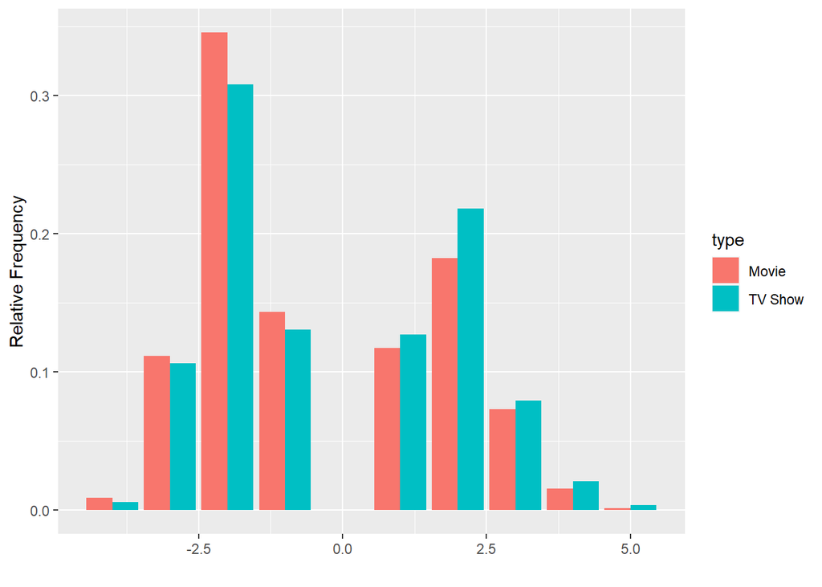

```r
df %>%
    unnest_tokens(input = description, output = word) %>%
    anti_join(get_stopwords()) %>%
    count(type, word, sort = TRUE) %>%
    group_by(type) %>%
    inner_join(get_sentiments("afinn")) %>%
    mutate(sentiment = value) %>%
    filter(!is.na(sentiment)) %>%
    count(sentiment, sort = TRUE) %>%
    group_by(type) %>%
    mutate(n = n/sum(n)) %>%
    ggplot(aes(sentiment, n, fill= type))+geom_col(position = 'dodge')+
    labs(y='Relative Frequency', x ='')
```

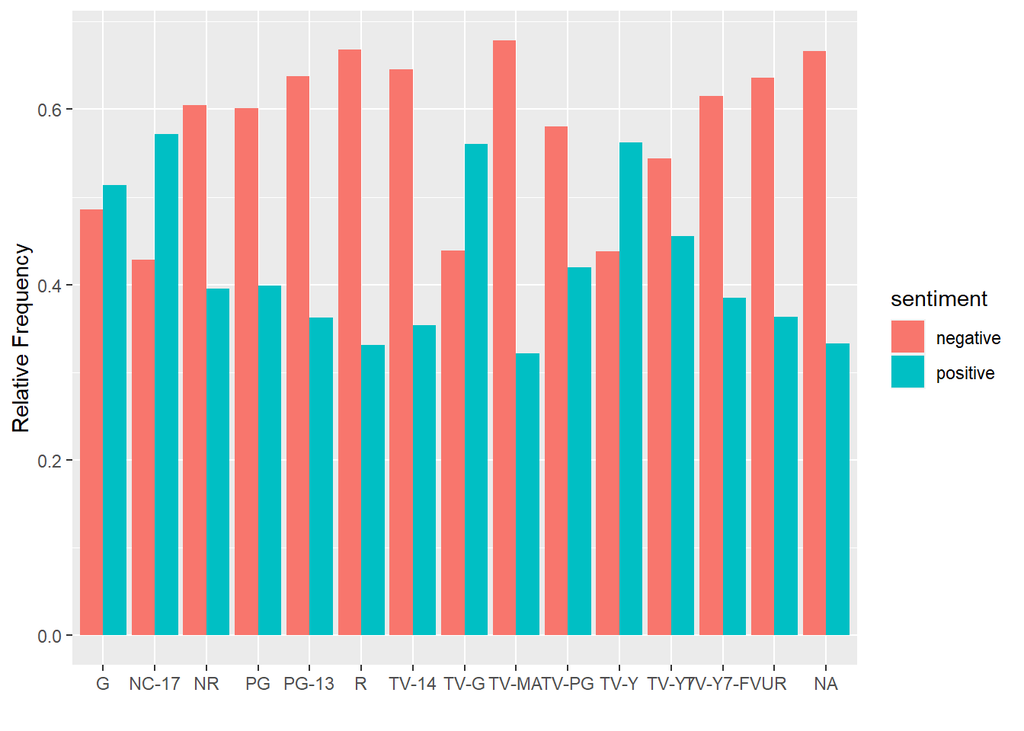

```r
df %>%
    unnest_tokens(input = description, output = word) %>%
    anti_join(get_stopwords()) %>%
    count(rating, word, sort = TRUE) %>%
    group_by(rating) %>%
    inner_join(get_sentiments("bing")) %>%
    filter(!is.na(sentiment)) %>%
    count(sentiment, sort = TRUE) %>%
    group_by(rating) %>%
    mutate(n = n/sum(n)) %>%
    ggplot(aes(rating, n, fill=sentiment))+geom_col(position = 'dodge')+
    labs(y='Relative Frequency', x ='')
```

## 4. Modeling

We build a model to predict the type of a video (movies vs. tv show) from its description. First we need to convert the description (text) to numeric values. We use `TF-IDF` method to convert the text to numeric variables.

- TF (Term Frequency) = (Number of times term t appears in a document) / (Total number of terms in the document).
- IDF (Inverse Document Frequency) = log_e(Total number of documents / Number of documents with term t in it).
- TF-IDF = TF * IDF

Source: http://www.tfidf.com/

```r
library(caret)
library(themis)
library(textrecipes)

# Select data and set target
df <- df %>%
  mutate(target = type) %>%
  select(target, description)

# Convert text data to numeric variables
a <- recipe(target~description,
       data = df) %>%
  step_tokenize(description) %>%
  step_tokenfilter(description, max_tokens = 5) %>%
  step_tfidf(description) %>%
  step_normalize(all_numeric_predictors()) %>%
  step_smote(target) %>%
  prep()
df <- juice(a)

# Using Caret for modeling
set.seed(2020)
splitIndex <- createDataPartition(df$target, p = .01,
                                  list = FALSE)
df_train <- df[ splitIndex,]
df_test <- df[-splitIndex,]

forest_ranger <- train(target~., data=df_train,
                        method = "ranger")

pred <- predict(forest_ranger, df_test)

cm <- confusionMatrix(data = pred, reference = df_test$target)
cm$overall[1]
```

```
##  Accuracy
## 0.5107082
```

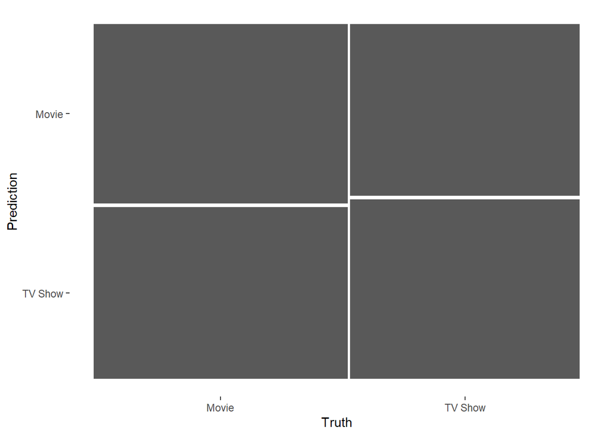

```r
d = data.frame(pred = pred, obs = df_test$target)
library(yardstick)
d %>% conf_mat(pred, obs) %>% autoplot
```

## Spam Message Detection

```r
library(textrecipes)
library(tidytext)
library(tidyverse)
library(themis)
library(caret)
df <- readr::read_csv('data/spam_message.csv')
# Select data and set target
df <- df %>%
    rename(target = Category, description = Message) %>%
    select(target, description)

# Convert text data to numeric variables
a <- recipe(target~description,
            data = df) %>%
    step_tokenize(description) %>%
    step_tokenfilter(description, max_tokens = 500) %>%
    step_tfidf(description) %>%
    step_normalize(all_numeric_predictors()) %>%
    step_smote(target) %>%
    prep()
df <- juice(a)


# Using Caret for modeling
set.seed(2021)
splitIndex <- createDataPartition(df$target, p = .7,
                                  list = FALSE)
df_train <- df[ splitIndex,]
df_test <- df[-splitIndex,]

forest_ranger <- train(target~., data=df_train,
                        method = "ranger")
pred <- predict(forest_ranger, df_test)

cm <- confusionMatrix(data = pred, reference = df_test$target)
cm$overall[1]
```

```
##  Accuracy
## 0.9934347
```

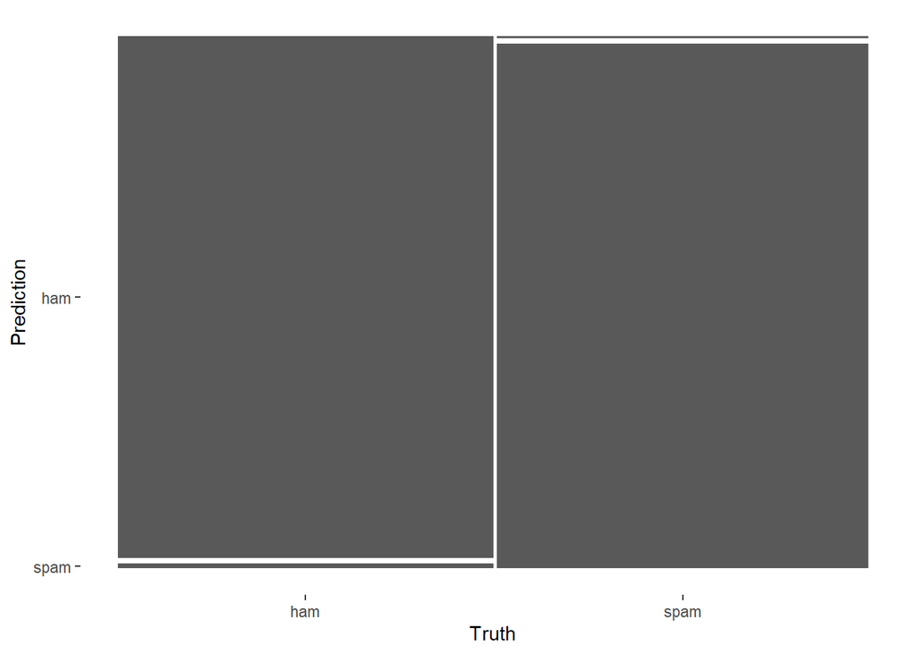

```r
d = data.frame(pred = pred, obs = df_test$target)
library(yardstick)
d %>% conf_mat(pred, obs) %>% autoplot
```